# 9. Final Summary: Is the Answer Really 30?

Comparing all eight populations

Author

Richa Vakharia

```r
source("R/clt_helpers.R")
files <- c("standard_normal", "six_sided_die", "exponential", "binomial_small_5_0_1_",
           "cauchy", "dependent_machine_failure", "non_identical_bernoulli_basketball_",
           "life_death_age_at_death_")
res <- lapply(file.path("results", paste0(files, ".rds")), readRDS)
names(res) <- sapply(res, `[[`, "name")
```

## 1 What I did

For each of 8 populations I simulated $B = 10,000$ samples at each of 27 sample sizes from $n = 1$ to $n = 500$, computed the sample mean of every sample, and checked whether the distribution of those means was “normal enough.”

**My “normal enough” standard** (applied the same way to every population):

| Check | Cutoff | Why |
| --- | --- | --- |
| \|Skewness\| | < 0.25 | Point where a histogram starts to look visibly lopsided; about 10x the Monte Carlo noise |
| \|Excess kurtosis\| | < 0.5 | Tails not noticeably heavier or lighter than normal; about 10x the noise |
| Q-Q correlation | > 0.998 | The Q-Q plot is close to a straight line |
| Stays passing | for every larger $n$ tested | So one lucky run can’t pick the answer |

I also looked at histograms, Q-Q plots, the Shapiro-Wilk test, and whether the simulated SE matched $\sigma/\sqrt n$. I did **not** use Shapiro-Wilk as a deciding rule, because with 5,000 values it rejects even tiny, unimportant departures (it rejected the *actual normal* at a couple of sample sizes and the die at almost every $n$).

## 2 Results table

```r
assumption <- c("All met (control)", "All met", "All met", "All met",
                "Finite variance FAILS", "Independence FAILS",
                "Identical distribution FAILS", "All met")
pop_skew <- c("0", "0", "2", "1.19", "undefined", "2.89 (long run)", "-2.67 to 0 (varies by shot)", "-0.86")

summary_tab <- do.call(rbind, lapply(seq_along(res), function(i) {
  r <- res[[i]]; t <- r$table
  at <- if (is.na(r$n_star)) t[nrow(t), ] else t[t$n == r$n_star, ]
  data.frame(
    Population = r$name,
    `CLT assumption` = assumption[i],
    `Population skewness` = pop_skew[i],
    `Smallest n judged normal` = ifelse(is.na(r$n_star), "None (fails at all n)", r$n_star),
    `Skewness at chosen n` = round(at$skewness, 3),
    `Excess kurtosis at chosen n` = round(at$ex_kurt, 3),
    `Q-Q cor at chosen n` = round(at$qq_cor, 4),
    `Sim SE / (sigma/sqrt n), n>=10` = if (all(is.na(t$se_ratio))) "undefined" else
      paste0(round(min(t$se_ratio[t$n >= 10]), 2), " to ", round(max(t$se_ratio[t$n >= 10]), 2)),
    `Passes at n = 30?` = ifelse(t$normal_enough[t$n == 30], "Yes", "No"),
    `Key observation` = r$note,
    check.names = FALSE
  )
}))
knitr::kable(summary_tab, row.names = FALSE)
```

| Population | CLT assumption | Population skewness | Smallest n judged normal | Skewness at chosen n | Excess kurtosis at chosen n | Q-Q cor at chosen n | Sim SE / (sigma/sqrt n), n>=10 | Passes at n = 30? | Key observation |
| --- | --- | --- | --- | --- | --- | --- | --- | --- | --- |
| Standard Normal | All met (control) | 0 | 1 | 0.018 | -0.027 | 0.9999 | 0.98 to 1.01 | Yes | Exactly normal at every n; shows the Monte Carlo noise floor |
| Six-Sided Die | All met | 0 | 10 | 0.011 | -0.085 | 0.9985 | 0.99 to 1.01 | Yes | Symmetric, so only light tails + discreteness slow it down |
| Exponential | All met | 2 | 70 | 0.202 | -0.017 | 0.9988 | 0.99 to 1.01 | No | Skewness 2/sqrt(n) is the bottleneck; n = 30 is not enough |
| Binomial Small (5, 0.1) | All met | 1.19 | 80 | 0.118 | 0.007 | 0.9984 | 0.99 to 1.02 | No | Skewness fine by ~30 but discreteness keeps Q-Q plot stair-stepped |
| Cauchy | Finite variance FAILS | undefined | None (fails at all n) | 99.916 | 9985.764 | 0.0443 | undefined | No | Infinite variance: IQR of the mean stays at 2 for every n |
| Dependent Machine Failure | Independence FAILS | 2.89 (long run) | 300 | 0.191 | 0.075 | 0.9989 | 0.84 to 0.86 | No | Not independent: naive SE ~15% too big, slow convergence |
| Non-identical Bernoulli (basketball) | Identical distribution FAILS | -2.67 to 0 (varies by shot) | 125 | -0.028 | -0.069 | 0.9982 | 0.99 to 1.02 | No | Not identical, but CLT still works; same pace as iid p = 0.7 |
| Life/Death (age at death) | All met | -0.86 | 12 | -0.234 | -0.114 | 0.9980 | 0.99 to 1.01 | Yes | Bimodal but bounded; bumps vanish by n = 2, mild left skew |

(For the Cauchy, the shape columns show $n = 500$, the largest $n$ tested. For the basketball model, “SE” uses the correct non-identical formula. For the dependent process, it uses the naive $\sigma/\sqrt n$.)

## 3 Convergence across populations

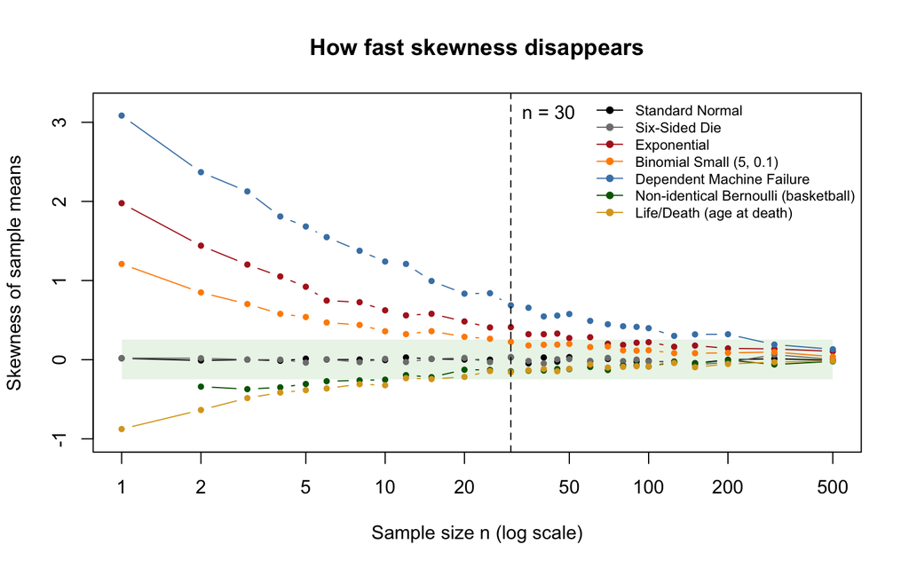

```r
cols <- c("black", "gray50", "firebrick", "darkorange", "purple", "steelblue", "darkgreen", "goldenrod")
plot(NA, xlim = c(1, 500), ylim = c(-1, 3.2), log = "x",
     xlab = "Sample size n (log scale)", ylab = "Skewness of sample means",
     main = "How fast skewness disappears")
rect(1, -skew_cut, 500, skew_cut, col = rgb(0, 0.6, 0, 0.1), border = NA)
for (i in seq_along(res)) {
  if (res[[i]]$name == "Cauchy") next
  t <- res[[i]]$table
  lines(t$n, t$skewness, type = "b", pch = 19, cex = 0.6, col = cols[i])
}
abline(v = 30, lty = 2)
text(30, 3.1, "n = 30", pos = 4)
legend("topright", names(res)[names(res) != "Cauchy"], col = cols[-5], lty = 1,
       pch = 19, cex = 0.75, bty = "n")
```

The shaded band is my $|\text{skewness}| < 0.25$ zone. (Cauchy is left off because its skewness is in the dozens and jumps around randomly.)

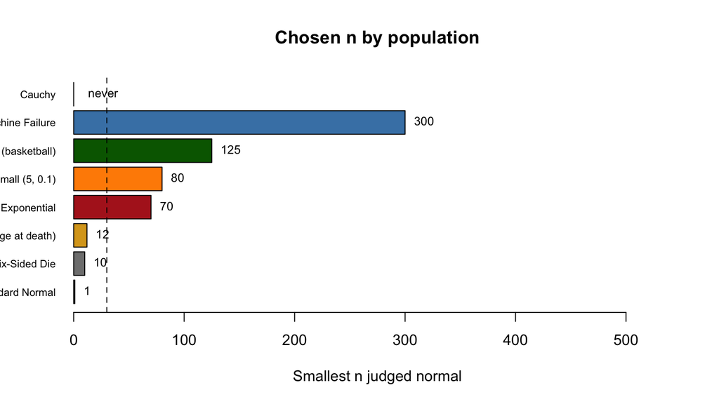

```r
ns <- sapply(res, function(r) ifelse(is.na(r$n_star), NA, r$n_star))
ord <- order(ns, na.last = TRUE)
bp <- barplot(ifelse(is.na(ns[ord]), 0, ns[ord]), horiz = TRUE, las = 1,
              names.arg = names(ns)[ord], col = cols[ord], xlim = c(0, 550),
              xlab = "Smallest n judged normal", cex.names = 0.7,
              main = "Chosen n by population")
abline(v = 30, lty = 2)
text(ifelse(is.na(ns[ord]), 5, ns[ord]), bp,
     ifelse(is.na(ns[ord]), "never", ns[ord]), pos = 4, cex = 0.8)
```

## 4 Answering the big questions

### 4.1 Is there a universal rule like $n = 30$?

**No.** My chosen $n$ ranged from 1 (normal) to 300 (dependent process), and for the Cauchy no $n$ works at all. Only 3 of the 8 populations passed my standard at $n = 30$. The “30” rule works for populations that are already roughly symmetric (normal, die, age-at-death) and fails for skewed ones like the exponential, where the skewness of $\bar X$ is still $2/\sqrt{30} \approx 0.37$.

A better rule than “30” for i.i.d. data is to look at the population’s skewness $g_1$. Since the skewness of $\bar X$ is $g_1/\sqrt n$, you need roughly

$$n \gtrsim \left(\frac{g_1}{0.25}\right)^2$$

for my standard. This predicted the exponential (64 predicted, 70 found) and the age-at-death distribution (12 predicted, 12 found) really well.

### 4.2 Which populations converged fastest and slowest, and why?

- **Fastest:** the normal (already normal), the die, and the age-at-death distribution. All three have little or no skewness and bounded or light tails.
- **Middle:** the exponential and the small binomial. The exponential is slowed by **skewness**. The binomial is slowed by **skewness plus discreteness**: its skewness was fine by about $n = 30$, but the Q-Q plot stayed stair-stepped until $n = 80$.
- **Slowest:** the dependent machine-failure process, and the Cauchy never got there.

The main drivers were (1) **skewness**, (2) **tail weight**, and (3) **discreteness**. How “weird” the population looked mattered a lot less: the bimodal age-at-death distribution converged faster than the smooth exponential.

### 4.3 What happened when assumptions broke?

- **Heavy tails (Cauchy, infinite variance):** the CLT completely fails. The IQR of the sample mean stayed at about 2 for every $n$ from 1 to 500, so averaging 500 values was no better than 1. This is the only case where the CLT truly failed.
- **Dependence (machine failure):** the CLT still worked eventually, but it took about $n = 300$, and **the usual SE formula was wrong** by about 15% at every $n$. Since the correlation was negative, the real SE was *smaller* than $\sigma/\sqrt n$. With positive correlation it would be bigger. Either way, using the i.i.d. formula with dependent data gives wrong confidence intervals.
- **Non-identical (basketball):** barely mattered. The fatigue model behaved almost exactly like an i.i.d. 70% shooter. The general (Lyapunov) CLT covers this case as long as no single observation dominates. The only catch is that you have to use the right SE formula, $\frac1n\sqrt{\sum p_t(1-p_t)}$, not the one based on the average $p$.

### 4.4 The difference between “the SE formula works” and “the shape is normal”

One thing that came up over and over: $\sigma/\sqrt n$ was accurate (within about 2%) for every i.i.d. population with finite variance, **even at $n = 1$**, when the shape was nowhere near normal. The CLT is about the **shape** of the sampling distribution. The SE formula is a separate fact that’s true for any $n$ as long as the data are independent with finite variance. The two broke separately: dependence broke the SE formula, and skewness slowed down the shape.

## 5 Reproducibility

- Every simulation uses `set.seed(student_id + n)` where `student_id = 2418`, set right before each experiment. Each sample size gets its own seed so that different $n$ values don’t reuse the same random numbers (I learned this the hard way with the Cauchy; see `05_cauchy.qmd`).
- In `03_exponential.qmd` I reran the full exponential sweep with a different seed. The exact numbers changed but the conclusion (somewhere around 60 to 80, definitely not 30) didn’t.
- Everything uses base R plus `knitr`, so anyone can run `quarto render` and get the same results.

## 6 Limitations

- My cutoffs (0.25, 0.50, 0.998) are a judgment call. A stricter skewness cutoff like 0.1 would push the exponential to around $n = 400$. The *ranking* of populations wouldn’t change, though.
- My $n$ grid has gaps (for example 70, 80, 90), so the true cutoff could be anywhere between grid points.
- The Q-Q correlation punishes discrete distributions for being discrete, even when the overall bell shape is fine. Someone could reasonably say the binomial is “normal enough” at a smaller $n$ than mine.
- $B = 10{,}000$ means skewness estimates have noise of about $\pm 0.025$. Near the cutoff that can flip a decision by one grid step.